# Week Ten: Text as Data

## Text as data

## Working with text

- Text is an exceedingly complex form of data that is difficult to systematically analyze.
- Two common concepts:
  - *Regular expressions*
  - *Corpora*

## Regular expressions

## Case study: Shakespeare

Project Gutenberg: **www.gutenberg.org**

[figure not shown]

## Fetching Macbeth

```r
library(mdsr)
library(tidyverse)
macbeth_url <- "http://www.gutenberg.org/cache/epub/1129/pg1129.txt"
macbeth <- read_table("http://www.gutenberg.org/cache/epub/1129/pg1129.txt")
head(macbeth)
```

```
## # A tibble: 6 x 1
##   `This Etext file is presented by Project Gutenberg, in`
##   <chr>
## 1 cooperation with World Library, Inc., from their Library of the
## 2 Future and Shakespeare CDROMS.  Project Gutenberg often releases
## 3 Etexts that are NOT placed in the Public Domain!!
## 4 <NA>
## 5 *This Etext has certain copyright implications you should read!*
## 6 <NA>
```

```r
slice(macbeth, 500:530)
```

```
## # A tibble: 31 x 1
##    `This Etext file is presented by Project Gutenberg, in`
##    <chr>
##  1 And pour'd them down before him.
##  2 ANGUS. We are sent
##  3 To give thee, from our royal master, thanks;
##  4 Only to herald thee into his sight,
##  5 Not pay thee.
##  6 ROSS. And for an earnest of a greater honor,
##  7 He bade me, from him, call thee Thane of Cawdor.
##  8 In which addition, hail, most worthy Thane,
##  9 For it is thine.
## 10 BANQUO. What, can the devil speak true?
## # ... with 21 more rows
```

## Start simple

Begin by asking very fundamental questions:

1. How long is this play?
2. How many times does Macbeth speak?
3. Who speaks the most?

**1. How long is the play?**

We should be able to get a decent approximation by pulling out any header and footer.

```r
macbeth_inner <- macbeth %>%
  slice(271:3171)
dim(macbeth_inner)
```

```
## [1] 2901    1
```

Can this be improved?

**2. How many times does Macbeth speak?**

```r
class(macbeth)
```

```
## [1] "tbl_df"     "tbl"        "data.frame"
```

```r
names(macbeth) <- NULL
macbeth <- unlist(macbeth)
class(macbeth)
```

```
## [1] "character"
```

```r
head(macbeth)
```

```
## [1] "cooperation with World Library, Inc., from their Library of the"
## [2] "Future and Shakespeare CDROMS.  Project Gutenberg often releases"
## [3] "Etexts that are NOT placed in the Public Domain!!"
## [4] NA
## [5] "*This Etext has certain copyright implications you should read!*"
## [6] NA
```

**2. How many times does Macbeth speak?**

```r
macbeth_lines <- grep("MACBETH", unlist(macbeth), value = TRUE)
length(macbeth_lines)
```

```
## [1] 208
```

```r
head(macbeth_lines)
```

```
## [1] "THE TRAGEDY OF MACBETH"
## [2] "MACBETH, Thane of Glamis and Cawdor, a general in the King's"
## [3] "LADY MACBETH, his wife"
## [4] "MACBETH. So foul and fair a day I have not seen."
## [5] "MACBETH. Speak, if you can. What are you?"
## [6] "MACBETH. Stay, you imperfect speakers, tell me more."
```

## grep()

- Global regular expression print
- R function and command-line tool
- Needle in haystack paradigm
- Patterns specified through *regular expressions*

```r
grep(pattern = "MACBETH", x = unlist(macbeth), value = TRUE)
```

If `value = FALSE` (the default), it will return the **indices** of the matches instead of the values themselves.

## Regex

A syntax to specify a general pattern of interest in text. Often used for searching for matches to the pattern in a text document. The pattern lives inside `" "` and is build up from general elements.

- Character classes
- Quantifiers and Alternation
- Anchors

## Character classes

- `.` : any character except newline

```r
grep("MAC.", macbeth, value = TRUE)[1:3]
```

```
## [1] "MACHINE READABLE COPIES MAY BE DISTRIBUTED SO LONG AS SUCH COPIES"
## [2] "MACHINE READABLE COPIES OF THIS ETEXT, SO LONG AS SUCH COPIES"
## [3] "WITH PERMISSION.  ELECTRONIC AND MACHINE READABLE COPIES MAY BE"
```

```r
grep("MACBETH\\.", macbeth, value = TRUE)[1:3]
```

```
## [1] "MACBETH. So foul and fair a day I have not seen."
## [2] "MACBETH. Speak, if you can. What are you?"
## [3] "MACBETH. Stay, you imperfect speakers, tell me more."
```

To **escape** a special character, you must use a backslash (or two in R).

## Character classes

- `.` : any character except newline
- `\w \d \s` : word, digit, whitespace

```r
(a <- macbeth[510])
```

```
## [1] "MACBETH. The Thane of Cawdor lives. Why do you dress me"
```

```r
(a <- unlist(strsplit(a, "\\.")))
```

```
## [1] "MACBETH"                    " The Thane of Cawdor lives"
## [3] " Why do you dress me"
```

```r
grep("\\s", a, value = TRUE)
```

```
## [1] " The Thane of Cawdor lives" " Why do you dress me"
```

## Character classes

- `.` any character except newline
- `\w \d \s` : word, digit, whitespace
- `[abc]` : any of a, b, or c
- `[^abc]` : not a, b, or c
- `[a-g]` : character between a and g

## Anchors

- `^` : start of string
- `$` : end of string

```r
grep("me$", macbeth, value = TRUE)
```

```
##  [1] "So from that spring whence comfort seem'd to come"
##  [2] "MACBETH. The Thane of Cawdor lives. Why do you dress me"
##  [3] "When those that gave the Thane of Cawdor to me"
##  [4] "crown me"
##  [5] "Which shall to all our nights and days to come"
##  [6] "At what it did so freely? From this time"
##  [7] "LADY MACBETH. That which hath made them drunk hath made me"
##  [8] "LADY MACBETH. My hands are of your color, but I shame"
##  [9] "Come"
## [10] "devil-porter it no further. I had thought to have let in some"
## [11] "BANQUO. As far, my lord, as will fill up the time"
## [12] "Let every man be master of his time"
## [13] "When first they put the name of King upon me"
## [14] "Whose absence is no less material to me"
## [15] "Our hostess keeps her state, but in best time"
## [16] "Impostors to true fear, would well become"
## [17] "If trembling I inhabit then, protest me"
## [18] "And hums, as who should say, \"You'll rue the time"
## [19] "Even till destruction sicken, answer me"
## [20] "Is often laudable, to do good sometime"
## [21] "By many of these trains hath sought to win me"
## [22] "Into his power, and modest wisdom plucks me"
## [23] "pale. I tell you yet again, Banquo's buried; he cannot come"
## [24] "MENTEITH. Who then shall blame"
## [25] "YOUNG SIWARD. No, though thou call'st thyself a hotter name"
## [26] "MALCOLM. We shall not spend a large expense of time"
```

## Anchors

- `^` : start of string
- `$` : end of string

```r
grep("\\sme$", macbeth, value = TRUE)
```

```
##  [1] "MACBETH. The Thane of Cawdor lives. Why do you dress me"
##  [2] "When those that gave the Thane of Cawdor to me"
##  [3] "crown me"
##  [4] "LADY MACBETH. That which hath made them drunk hath made me"
##  [5] "When first they put the name of King upon me"
##  [6] "Whose absence is no less material to me"
##  [7] "If trembling I inhabit then, protest me"
##  [8] "Even till destruction sicken, answer me"
##  [9] "By many of these trains hath sought to win me"
## [10] "Into his power, and modest wisdom plucks me"
```

## Quantifiers and alternation

- `a*`: 0 or more of a
- `a+` : 1 or more of a
- `a?` : 0 or 1 of a
- `a{5}` `a{2,}` : exactly five, two or more a

```r
tail(grep("\\s{2,}", macbeth, value = TRUE))
```

```
## [1] "Brandish'd by man that's of a woman born.              Exit."
## [2] "And more I beg not.                           Exit. Alarums."
## [3] "Than terms can give thee out!                    They fight."
## [4] "ALL. Hail, King of Scotland!                         Flourish."
## [5] "WITH PERMISSION.  ELECTRONIC AND MACHINE READABLE COPIES MAY BE"
## [6] "COMMERCIALLY.  PROHIBITED COMMERCIAL DISTRIBUTION INCLUDES BY ANY"
```

## Quantifiers and alternation

- `a*`: 0 or more of a
- `a+` : 1 or more of a
- `a?` : 0 or 1 of a
- `a{5}` `a{2,}` : exactly five, two or more a
- `ab|cd` : match ab or cd

## Quantifiers and alternation

```r
grep("Thane of [F|G]", macbeth, value = TRUE)
```

```
## [1] "MACBETH, Thane of Glamis and Cawdor, a general in the King's"
## [2] "MACDUFF, Thane of Fife, a nobleman of Scotland"
## [3] "FIRST WITCH. All hail, Macbeth, hail to thee, Thane of Glamis!"
## [4] "By Sinel's death I know I am Thane of Glamis;"
## [5] "Beware the Thane of Fife. Dismiss me. Enough."
## [6] "LADY MACBETH. The Thane of Fife had a wife; where is she now?"
```

## Activity 8A

1. Identify first lines spoken by Lady Macbeth, Macbeth, or Macduff.
2. Match everything in the left column and nothing in the right.

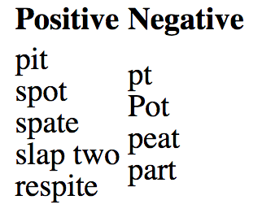

Using the `babynames` data,

1. Find the top ten boys' names that end in a vowel.
2. Create two top ten lists - one for boys and one for girls - for names ending with "joe", "jo", "Joe", or "Joe".
3. Find the name/names that involve the greatest number of consecutive consonants.

## Protip

[figure not shown]

## Start simple

Begin by asking very fundamental questions:

1. How long is this play?
2. How many times does Macbeth speak?
3. Who speaks the most?

**2. How many times does Macbeth speak?**

```r
mac_speaks <- grep("^MACBETH\\.", macbeth, value = TRUE)
head(mac_speaks)
```

```
## [1] "MACBETH. So foul and fair a day I have not seen."
## [2] "MACBETH. Speak, if you can. What are you?"
## [3] "MACBETH. Stay, you imperfect speakers, tell me more."
## [4] "MACBETH. Into the air, and what seem'd corporal melted"
## [5] "MACBETH. Your children shall be kings."
## [6] "MACBETH. And Thane of Cawdor too. Went it not so?"
```

```r
length(mac_speaks)
```

```
## [1] 146
```

**3. Who speaks the most?**

Focus on four characters and use `grepl()` to return a logical vector.

```r
Macbeth <- grepl("^MACBETH\\.", macbeth)
LadyMacbeth <- grepl("^LADY MACBETH\\.", macbeth)
Banquo <- grepl("^BANQUO\\.", macbeth)
Duncan <- grepl("^DUNCAN\\.", macbeth)
```

Sketch goal

```r
data.frame(Macbeth, LadyMacbeth, Banquo, Duncan) %>%
  mutate(line = 1:length(macbeth)) %>%
  gather(key = "character", value = "speak", -line)
```

```
##       line   character speak
## 1        1     Macbeth FALSE
## 2        2     Macbeth FALSE
## 3        3     Macbeth FALSE
## 4        4     Macbeth FALSE
## 5        5     Macbeth FALSE
## 6        6     Macbeth FALSE
## 7        7     Macbeth FALSE
## 8        8     Macbeth FALSE
## 9        9     Macbeth FALSE
## 10      10     Macbeth FALSE
## 11      11     Macbeth FALSE
## 12      12     Macbeth FALSE
## 13      13     Macbeth FALSE
## 14      14     Macbeth FALSE
```

[output cut: 12754 more lines]

```r
speaker_freq <- data.frame(Macbeth, LadyMacbeth, Banquo, Duncan) %>%
  mutate(line = 1:length(macbeth)) %>%
  gather(key = "character", value = "speak", -line) %>%
  mutate(speak = as.numeric(speak)) %>%
  filter(line > 218, line < 3712)
speaker_freq
```

```
##       line   character speak
## 1      219     Macbeth     0
## 2      220     Macbeth     0
## 3      221     Macbeth     0
## 4      222     Macbeth     0
## 5      223     Macbeth     0
## 6      224     Macbeth     0
## 7      225     Macbeth     0
## 8      226     Macbeth     0
## 9      227     Macbeth     0
## 10     228     Macbeth     0
## 11     229     Macbeth     0
## 12     230     Macbeth     0
## 13     231     Macbeth     0
## 14     232     Macbeth     0
```

[output cut: 11882 more lines]

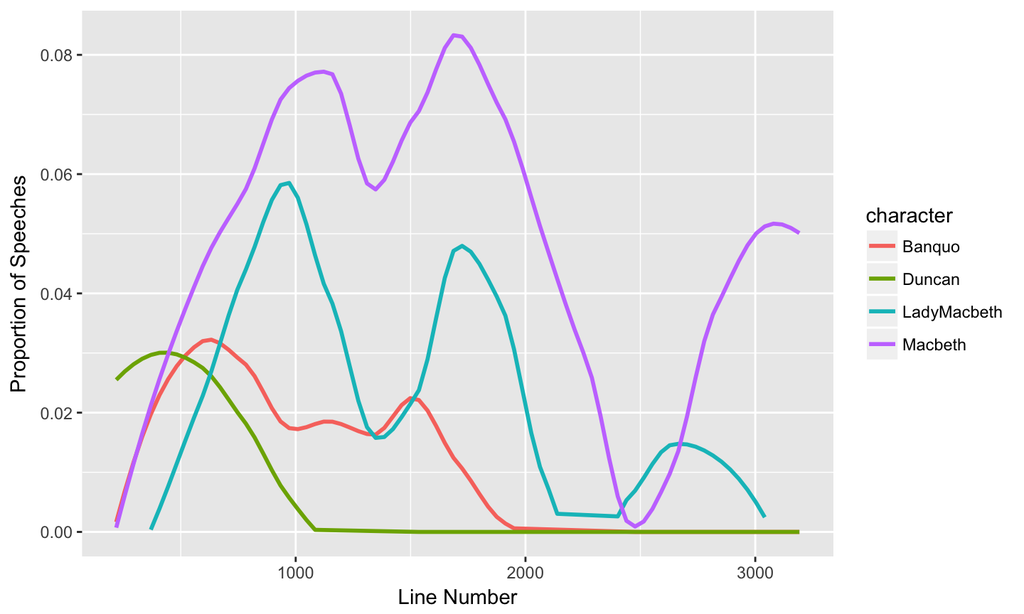

```r
ggplot(speaker_freq, aes(x = line, y = speak)) +
  geom_smooth(aes(col = character), method = "loess", se = FALSE, span = .4) +
  ylim(c(0, NA)) + xlab("Line Number") + ylab("Proportion of Speeches")
```

## Adding context

We can add in the act markers by extracting those line numbers.

```r
(acts_idx <- grep("^ACT [I|V]+", macbeth))
```

```
## [1]  274  922 1407 2014 2639
```

```r
(acts_labels <- str_extract(macbeth[acts_idx], "^ACT [I|V]+"))
```

```
## [1] "ACT I"   "ACT II"  "ACT III" "ACT IV"  "ACT V"
```

```r
acts <- data.frame(line = acts_idx, labels = acts_labels)
```

```r
ggplot(speaker_freq, aes(x = line, y = speak)) +
  geom_smooth(aes(col = character), method = "loess", se = FALSE, span = .4) +
  ylim(c(0, NA)) + xlab("Line Number") + ylab("Proportion of Speeches") +
  geom_vline(xintercept = acts_idx, color = "darkgray", lty = 3) +
  geom_text(data = acts, aes(y = 0.085, label = labels),
            hjust = "left", color = "darkgray")
```

[output not shown]

## Activity 8B

Select a different Shakespeare play and answer the same three questions.

1. How long is this play?
2. How many times does Macbeth speak?
3. Who speaks the most?

Instead of worry about bringing in URLs, use a package.

```r
library(gutenbergr)
gutenberg_works(author == "Shakespeare, William")
gutenberg_works(title == "Macbeth")
macbeth <- gutenberg_download(1533)
```